# Assignment 2

Faye Kollig

11/5/2019

## Introduction

In his article “Comic Books Are Still Made By Men, For Men And About Men”, Walt Hickey discusses how women appear in comic books, looking all the way back to the 60s and up to the present (2014) to see how representation has or hasn’t changed. He discusses the claim that the audience of comics has long been perceived to be young, white and male, and that this has informed the characters that are written - people like to read about people who look like them. However, young, white males are not the only people who read or enjoy the DC and Marvel comics universes (particularly evident with the success of Ms. Marvel, whose protagonist is female and an ethnic minority).

The question presented is what this unequal representation looks like, in terms not only of binary gender, but also nonbinary genders, goodness and badness of characters, and popularity of characters.

## Methods

The dataset of comic characters from Marvel and DC was gathered from fan Wikia pages and cleaned into a tidy dataset by Hickey for the purposes of the article. It contains a plethora of information about each of the 6,896 unique characters from the DC universe and 16,376 from Marvel, resulting in 23,272 unique observations (characters) listed. When it could be identified, 16 pieces of information were recorded about each character. Categorical variables include `name`, which comic `publisher` they belong to, identity (secret or public), alignment (goodness or badness), eye and hair color, whether they are living or dead, and whether they are a sexual identity minority. The dataset also contains both the page ID and the URL of the place where the character can be found on the Wikia page, and the total number of `appearances` in comics as of 2014. The `day`, `month`, and `year` of the character’s first appearance is also noted.

For the purposes of studying the questions posed, this report focuses on the publisher (DC or Marvel), the alignment (Good Character or Bad Character), the number of appearances, and the sex of each character. The `sex` variable has six levels: characters can be Female Characters, Male Characters, or one of four nonbinary identities (agender, genderless, genderfluid, and transgender).

## Results

### Gender Representation of New Characters

As seen in the graph below, of the total new characters created each year, the percentage that are male is overwhelming. Although there is definitely a trend towards the solid ‘Percent of new male and female characters are equal’ line, the percentage of new characters that are female never exceeds the dashed 40% mark.

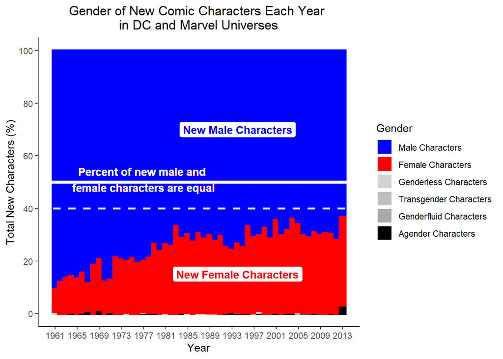

Aside from male and female representation, nonbinary representation is clearly not even at play in this data. There are only 68 characters that are not male or female, with only two of these appearing more than 100 times (Loki and Venom, seen below). Of these nonbinary characters, the vast majority are aliens, robots, computers or monsters of some sort. Loki, the most appearing of the nonbinary characters, is clearly represented as male in motion picture and pop culture. Furthermore, the only transgender character among the 68, Daystar from the DC universe, is not even listed as transgender on all comic forums - on comicvine.gamespot.com, Daystar is listed only as male.

```
## # A tibble: 10 x 4
##    publisher name                          sex                  appearances
##    <chr>     <chr>                         <fct>                      <dbl>
##  1 Marvel    Loki Laufeyson (Earth-616)    Genderfluid Charact~         532
##  2 Marvel    Venom (Symbiote) (Earth-616)  Agender Characters           348
##  3 Marvel    Carnage (Symbiote) (Earth-61~ Agender Characters            61
##  4 Marvel    Captain Universe (Earth-616)  Agender Characters            54
##  5 DC        Larvox (New Earth)            Genderless Characte~          36
##  6 Marvel    Xavin (Earth-616)             Genderfluid Charact~          33
##  7 Marvel    Living Brain (Earth-616)      Agender Characters            32
##  8 DC        Quislet (Pre-Zero Hour)       Genderless Characte~          31
##  9 DC        Apros (New Earth)             Genderless Characte~          31
## 10 DC        Kelex (New Earth)             Genderless Characte~          30
```

### Gender and Frequency of Appearance

Setting aside the lack of representation in comics of nonbinary identities, of the 23,272 unique characters, only 5804 are female, and of the top 20 most frequently appearing characters, only 2 are female (see table below).

```
## # A tibble: 20 x 4
##    publisher name                                appearances sex
##    <chr>     <chr>                                     <dbl> <fct>
##  1 Marvel    Spider-Man (Peter Parker)                  4043 Male Characte~
##  2 Marvel    Captain America (Steven Rogers)            3360 Male Characte~
##  3 DC        Batman (Bruce Wayne)                       3093 Male Characte~
##  4 Marvel    "Wolverine (James \\\"Logan\\\" Ho~        3061 Male Characte~
##  5 Marvel    "Iron Man (Anthony \\\"Tony\\\" St~        2961 Male Characte~
##  6 DC        Superman (Clark Kent)                      2496 Male Characte~
##  7 Marvel    Thor (Thor Odinson)                        2258 Male Characte~
##  8 Marvel    Benjamin Grimm (Earth-616)                 2255 Male Characte~
##  9 Marvel    Reed Richards (Earth-616)                  2072 Male Characte~
## 10 Marvel    Hulk (Robert Bruce Banner)                 2017 Male Characte~
## 11 Marvel    Scott Summers (Earth-616)                  1955 Male Characte~
## 12 Marvel    Jonathan Storm (Earth-616)                 1934 Male Characte~
## 13 Marvel    Henry McCoy (Earth-616)                    1825 Male Characte~
## 14 Marvel    Susan Storm (Earth-616)                    1713 Female Charac~
## 15 DC        Green Lantern (Hal Jordan)                 1565 Male Characte~
## 16 Marvel    Namor McKenzie (Earth-616)                 1528 Male Characte~
## 17 Marvel    Ororo Munroe (Earth-616)                   1512 Female Charac~
## 18 Marvel    Clinton Barton (Earth-616)                 1394 Male Characte~
## 19 Marvel    Matthew Murdock (Earth-616)                1338 Male Characte~
## 20 DC        James Gordon (New Earth)                   1316 Male Characte~
```

Looking at gender in total appearances, females also trail males by a long way. The DC universe contains significantly fewer characters, but the percentage of total appearances that are female is 32.3% for DC and 28.3% for Marvel, both of which fall far short of a 50-50 representation.

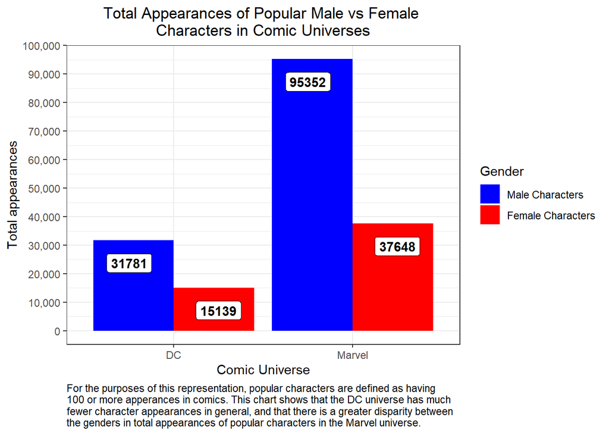

### Goodness, Badness, and Gender

In a theoretically even representation of male, female, good and bad, the color of each bar in the graph below would change at each dotted white line, showing that 25% of characters were good and female, 25% bad and female, 25% bad and male, and 25% good and male. The data shows a story of a dominant amount of male villains in both universes (shown in light blue). In the DC universe the amount of male villains increases past the 80s and in the Marvel universe the amount of male villains decreases past the 90s.

While the proportions of gender and alignment are relatively scattered in the DC universe, especially in the early years when the data was less complete, there is a clear trend in the Marvel universe. Most new Marvel characters are male and bad, but the categories have trended towards evening out in the past couple decades. Because the proportion of characters that are female never exceeds 40% (as seen earlier), it never reaches that equilibrium, but since the late 90s more good male characters and fewer bad male characters are created.

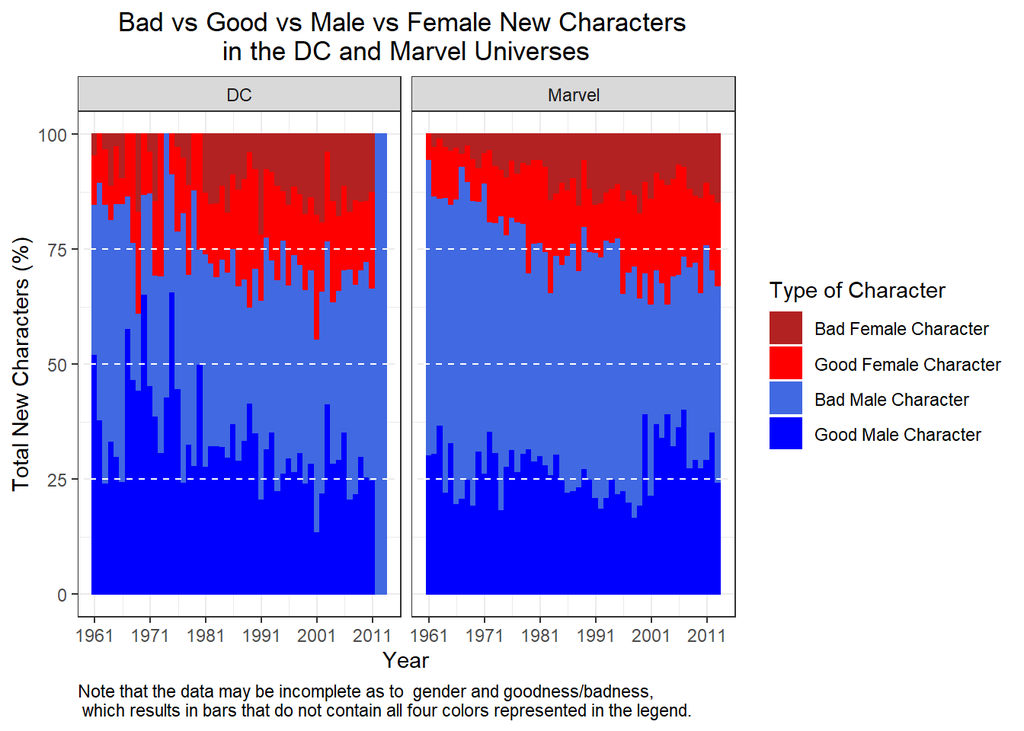

When focusing only on female characters, a slightly higher propotion of female characters are good than bad, but the difference between the two alignments is not as significant as it is in male characters.

## Conclusion

This dataset shows a clear pattern of unequal gender representation in the DC and Marvel universes. Females represent a minority of new characters, and an even smaller minority of the most popular characters. Though Marvel has more than twice as many total character apperarances as DC, women comprise only about 30% of each. Aside from females, nonbinary identities are even more poorly represented, making 0.2% of characters in general. Female characters tend to be more good than bad, and males more bad than good, but across the board, there is not an equal representation of both. The data shows that comic characters certainly seem to be created for a male audience that enjoys reading about male characters, from 1961 all the way to 2014.